# Cronbah’s Alpha

Daniel Chen

Last compiled on 13 October, 2021

# Unidimensional

From [@zieglerTestingUnidimensionalityItems2015]

> According to thisprinciple, a set of items is seen as unidimensional if thereare no correlated residuals between the items once the var-iance due to the latent construct is controlled for.

> If all items mea-sure the same processes to the same extent, they can still beconsidered unidimensional

> EFA is not really an appropriatetechnique totestunidimensionality. Rather than that EFAis a viable approach to deriving hypotheses regarding the possible number of factors underlying the item intercorrela-tions. Thus, EFA should not be sold in a paper as providingevidence regarding unidimensionality.

also: https://data.library.virginia.edu/using-and-interpreting-cronbachs-alpha/

# Cronbah’s Alpha

## All

```r
wide_survey_likert %>%
  data.matrix() %>%
  psych::alpha()
```

```
## Some items ( Q3.7 Q5.1 ) were negatively correlated with the total scale and
## probably should be reversed.
## To do this, run the function again with the 'check.keys=TRUE' option
```

```
##
## Reliability analysis
## Call: psych::alpha(x = .)
##
##   raw_alpha std.alpha G6(smc) average_r S/N   ase mean   sd median_r
##       0.92      0.92    0.97      0.34  12 0.012  3.2 0.89     0.38
##
##  lower alpha upper     95% confidence boundaries
## 0.89 0.92 0.94
##
##  Reliability if an item is dropped:
##        raw_alpha std.alpha G6(smc) average_r S/N alpha se var.r med.r
## Q3.1        0.91      0.91    0.96      0.32  10    0.014 0.087  0.37
## Q3.3        0.91      0.91    0.96      0.32  10    0.014 0.086  0.37
## Q3.4        0.91      0.91    0.96      0.32  11    0.014 0.087  0.37
## Q3.5        0.91      0.91    0.96      0.32  10    0.014 0.087  0.37
## Q3.6        0.92      0.92    0.97      0.34  12    0.012 0.095  0.41
## Q3.7        0.93      0.93    0.97      0.38  14    0.011 0.071  0.41
## Q4.1        0.92      0.92    0.97      0.35  12    0.012 0.094  0.41
## Q4.2        0.91      0.92    0.97      0.33  11    0.013 0.094  0.37
## Q4.3        0.91      0.92    0.97      0.33  11    0.013 0.093  0.38
## Q4.4        0.91      0.92    0.97      0.34  11    0.013 0.094  0.38
## Q5.1        0.93      0.93    0.97      0.38  14    0.010 0.073  0.41
## Q5.2        0.91      0.91    0.97      0.32  11    0.013 0.091  0.37
## Q6.1        0.91      0.92    0.96      0.33  11    0.013 0.092  0.37
## Q6.2        0.91      0.92    0.96      0.33  11    0.013 0.092  0.38
## Q6.3        0.92      0.92    0.97      0.33  11    0.013 0.092  0.38
## Q6.4        0.92      0.92    0.97      0.34  11    0.013 0.094  0.39
## Q7.2_1      0.92      0.92    0.97      0.36  12    0.012 0.091  0.41
## Q7.2_2      0.91      0.91    0.96      0.32  10    0.015 0.086  0.37
## Q7.2_3      0.91      0.91    0.97      0.33  11    0.013 0.092  0.37
## Q7.2_4      0.91      0.91    0.96      0.32  11    0.014 0.090  0.37
## Q7.2_5      0.91      0.91    0.96      0.32  10    0.014 0.088  0.37
## Q7.2_6      0.91      0.92    0.96      0.33  11    0.013 0.089  0.38
## Q7.2_7      0.91      0.92    0.96      0.34  11    0.013 0.090  0.38
##
##  Item statistics
##         n  raw.r std.r r.cor r.drop mean   sd
## Q3.1   57  0.885  0.86  0.87   0.87  2.3 1.21
## Q3.3   57  0.869  0.84  0.85   0.84  3.1 2.04
```

[output cut: 32 more lines]

```
## Q4.3   0.49 0.11 0.26 0.14 0.00 0.00 0.00 0.00    0
## Q4.4   0.65 0.09 0.11 0.16 0.00 0.00 0.00 0.00    0
## Q5.1   0.05 0.33 0.25 0.14 0.02 0.07 0.04 0.11    0
## Q5.2   0.12 0.54 0.05 0.05 0.16 0.07 0.00 0.00    0
## Q6.1   0.19 0.14 0.46 0.21 0.00 0.00 0.00 0.00    0
## Q6.2   0.18 0.16 0.49 0.18 0.00 0.00 0.00 0.00    0
## Q6.3   0.18 0.21 0.44 0.18 0.00 0.00 0.00 0.00    0
## Q6.4   0.46 0.21 0.18 0.16 0.00 0.00 0.00 0.00    0
## Q7.2_1 0.00 0.00 0.00 0.05 0.12 0.33 0.49 0.00    0
## Q7.2_2 0.37 0.16 0.09 0.05 0.11 0.07 0.16 0.00    0
## Q7.2_3 0.02 0.05 0.04 0.04 0.32 0.30 0.25 0.00    0
## Q7.2_4 0.14 0.05 0.12 0.23 0.19 0.12 0.14 0.00    0
## Q7.2_5 0.28 0.14 0.14 0.07 0.12 0.12 0.12 0.00    0
## Q7.2_6 0.09 0.04 0.02 0.32 0.09 0.16 0.30 0.00    0
## Q7.2_7 0.09 0.02 0.02 0.32 0.07 0.14 0.35 0.00    0
```

```r
wide_survey_likert %>%
  dplyr::select(-Q3.7, -Q5.1) %>%
  data.matrix() %>%
  psych::alpha()
```

```
##
## Reliability analysis
## Call: psych::alpha(x = .)
##
##   raw_alpha std.alpha G6(smc) average_r S/N   ase mean sd median_r
##       0.94      0.94    0.97      0.44  16 0.009  3.2  1     0.43
##
##  lower alpha upper     95% confidence boundaries
## 0.92 0.94 0.96
##
##  Reliability if an item is dropped:
##        raw_alpha std.alpha G6(smc) average_r S/N alpha se var.r med.r
## Q3.1        0.94      0.94    0.97      0.42  15   0.0099 0.044  0.43
## Q3.3        0.94      0.94    0.97      0.42  15   0.0102 0.043  0.42
## Q3.4        0.94      0.94    0.97      0.43  15   0.0100 0.044  0.43
## Q3.5        0.94      0.94    0.97      0.42  15   0.0098 0.044  0.43
## Q3.6        0.94      0.94    0.97      0.45  17   0.0086 0.046  0.45
## Q4.1        0.94      0.94    0.98      0.46  17   0.0089 0.044  0.45
## Q4.2        0.94      0.94    0.97      0.44  15   0.0092 0.050  0.43
## Q4.3        0.94      0.94    0.97      0.44  16   0.0094 0.048  0.43
## Q4.4        0.94      0.94    0.97      0.44  16   0.0091 0.049  0.44
## Q5.2        0.94      0.94    0.97      0.43  15   0.0097 0.047  0.42
## Q6.1        0.94      0.94    0.97      0.43  15   0.0091 0.048  0.43
## Q6.2        0.94      0.94    0.97      0.44  16   0.0091 0.048  0.43
## Q6.3        0.94      0.94    0.97      0.44  16   0.0091 0.048  0.44
## Q6.4        0.94      0.94    0.97      0.44  16   0.0090 0.048  0.43
## Q7.2_1      0.94      0.95    0.98      0.47  18   0.0087 0.039  0.45
## Q7.2_2      0.94      0.94    0.97      0.42  15   0.0105 0.043  0.42
## Q7.2_3      0.94      0.94    0.97      0.43  15   0.0096 0.049  0.43
## Q7.2_4      0.94      0.94    0.97      0.43  15   0.0098 0.047  0.43
## Q7.2_5      0.94      0.94    0.97      0.42  15   0.0103 0.045  0.42
## Q7.2_6      0.94      0.94    0.97      0.43  15   0.0095 0.046  0.43
## Q7.2_7      0.94      0.94    0.97      0.44  16   0.0092 0.045  0.43
##
##  Item statistics
##         n raw.r std.r r.cor r.drop mean   sd
## Q3.1   57  0.88  0.86  0.86   0.87  2.3 1.21
## Q3.3   57  0.88  0.85  0.85   0.85  3.1 2.04
## Q3.4   57  0.84  0.80  0.80   0.81  2.2 1.70
## Q3.5   57  0.86  0.84  0.84   0.85  2.0 1.17
```

[output cut: 26 more lines]

```
## Q4.2   0.04 0.19 0.47 0.30 0.00 0.00 0.00    0
## Q4.3   0.49 0.11 0.26 0.14 0.00 0.00 0.00    0
## Q4.4   0.65 0.09 0.11 0.16 0.00 0.00 0.00    0
## Q5.2   0.12 0.54 0.05 0.05 0.16 0.07 0.00    0
## Q6.1   0.19 0.14 0.46 0.21 0.00 0.00 0.00    0
## Q6.2   0.18 0.16 0.49 0.18 0.00 0.00 0.00    0
## Q6.3   0.18 0.21 0.44 0.18 0.00 0.00 0.00    0
## Q6.4   0.46 0.21 0.18 0.16 0.00 0.00 0.00    0
## Q7.2_1 0.00 0.00 0.00 0.05 0.12 0.33 0.49    0
## Q7.2_2 0.37 0.16 0.09 0.05 0.11 0.07 0.16    0
## Q7.2_3 0.02 0.05 0.04 0.04 0.32 0.30 0.25    0
## Q7.2_4 0.14 0.05 0.12 0.23 0.19 0.12 0.14    0
## Q7.2_5 0.28 0.14 0.14 0.07 0.12 0.12 0.12    0
## Q7.2_6 0.09 0.04 0.02 0.32 0.09 0.16 0.30    0
## Q7.2_7 0.09 0.02 0.02 0.32 0.07 0.14 0.35    0
```

## Programming Q3

Q3.7. How often do you currently use Databases (SQL, Access, etc.)

1. Never
2. Less than once per year
3. Several times per year
4. Monthly
5. Weekly
6. Daily

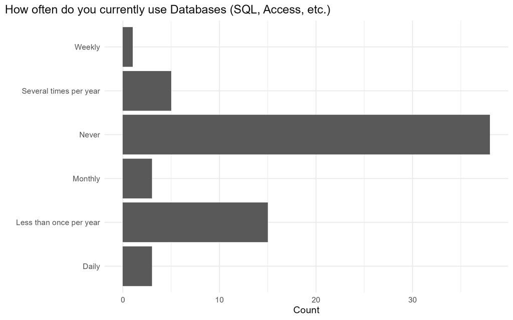

```r
knitr::include_graphics(here::here("output/survey/01-self_assessment/Q3.7.png"))
```

Our users almost never work with databases. Causes negative correlation.

```r
wide_survey_likert %>%
  dplyr::select(starts_with("Q3"), -Q3.7) %>%
  data.matrix() %>%
  psych::alpha()
```

```
##
## Reliability analysis
## Call: psych::alpha(x = .)
##
##   raw_alpha std.alpha G6(smc) average_r S/N   ase mean  sd median_r
##       0.87      0.88     0.9      0.59 7.1 0.024  2.3 1.2     0.83
##
##  lower alpha upper     95% confidence boundaries
## 0.82 0.87 0.92
##
##  Reliability if an item is dropped:
##      raw_alpha std.alpha G6(smc) average_r  S/N alpha se   var.r med.r
## Q3.1      0.81      0.81    0.86      0.52  4.4   0.0360 0.15630  0.53
## Q3.3      0.80      0.81    0.84      0.51  4.2   0.0442 0.12957  0.52
## Q3.4      0.80      0.82    0.86      0.53  4.5   0.0397 0.14009  0.53
## Q3.5      0.81      0.81    0.85      0.51  4.2   0.0366 0.14746  0.52
## Q3.6      0.94      0.96    0.95      0.86 25.3   0.0086 0.00098  0.86
##
##  Item statistics
##       n raw.r std.r r.cor r.drop mean  sd
## Q3.1 57  0.91  0.92  0.91   0.87  2.3 1.2
## Q3.3 57  0.95  0.93  0.95   0.89  3.1 2.0
## Q3.4 57  0.92  0.90  0.90   0.85  2.2 1.7
## Q3.5 57  0.93  0.93  0.94   0.90  2.0 1.2
## Q3.6 57  0.38  0.42  0.20   0.18  2.1 1.3
##
## Non missing response frequency for each item
##         1    2    3    4    5    6    7 miss
## Q3.1 0.37 0.19 0.26 0.14 0.04 0.00 0.00    0
## Q3.3 0.25 0.25 0.21 0.09 0.02 0.05 0.14    0
## Q3.4 0.56 0.18 0.05 0.05 0.07 0.09 0.00    0
## Q3.5 0.51 0.18 0.14 0.18 0.00 0.00 0.00    0
## Q3.6 0.47 0.19 0.12 0.16 0.05 0.00 0.00    0
```

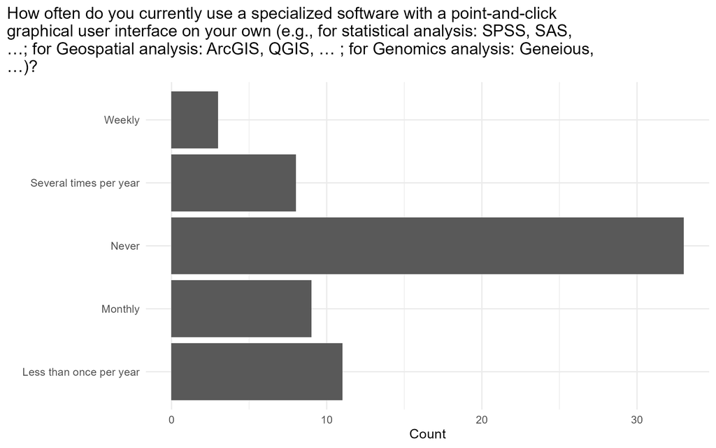

```r
knitr::include_graphics(here::here("output/survey/01-self_assessment/Q3.6.png"))
```

```r
wide_survey_likert %>%
  dplyr::select(starts_with("Q3"), -Q3.7, -Q3.6) %>%
  data.matrix() %>%
  alpha()
```

```
##
## Reliability analysis
## Call: alpha(x = .)
##
##   raw_alpha std.alpha G6(smc) average_r S/N    ase mean  sd median_r
##       0.94      0.96    0.95      0.86  25 0.0086  2.4 1.5     0.86
##
##  lower alpha upper     95% confidence boundaries
## 0.93 0.94 0.96
##
##  Reliability if an item is dropped:
##      raw_alpha std.alpha G6(smc) average_r S/N alpha se   var.r med.r
## Q3.1      0.93      0.96    0.94      0.88  22    0.010 0.00105  0.90
## Q3.3      0.92      0.94    0.91      0.84  16    0.015 0.00019  0.84
## Q3.4      0.92      0.95    0.93      0.87  21    0.013 0.00078  0.87
## Q3.5      0.93      0.95    0.93      0.86  19    0.012 0.00135  0.87
##
##  Item statistics
##       n raw.r std.r r.cor r.drop mean  sd
## Q3.1 57  0.92  0.93  0.90   0.88  2.3 1.2
## Q3.3 57  0.97  0.97  0.96   0.94  3.1 2.0
## Q3.4 57  0.95  0.94  0.91   0.90  2.2 1.7
## Q3.5 57  0.94  0.95  0.93   0.91  2.0 1.2
##
## Non missing response frequency for each item
##         1    2    3    4    5    6    7 miss
## Q3.1 0.37 0.19 0.26 0.14 0.04 0.00 0.00    0
## Q3.3 0.25 0.25 0.21 0.09 0.02 0.05 0.14    0
## Q3.4 0.56 0.18 0.05 0.05 0.07 0.09 0.00    0
## Q3.5 0.51 0.18 0.14 0.18 0.00 0.00 0.00    0
```

7.2:

- I believe having access to the original, raw data is important to be able to repeat an analysis. (1)
- I can write a small program, script, or macro to address a problem in my own work. (2)
- I know how to search for answers to my technical questions online. (3)
- While working on a programming project, if I got stuck, I can find ways of overcoming the problem. (4)
- I am confident in my ability to make use of programming software to work with data. (5)
- Using a programming language (like R or Python) can make my analyses easier to reproduce. (6)
- Using a programming language (like R or Python) can make me more efficient at working with data. (7)

```r
wide_survey_likert %>%
  dplyr::select(starts_with("Q3"), -Q3.7, -Q3.6, Q7.2_2, Q7.2_3, Q7.2_4, Q7.2_5, Q7.2_6, Q7.2_7) %>%
  data.matrix() %>%
  alpha()
```

```
##
## Reliability analysis
## Call: alpha(x = .)
##
##   raw_alpha std.alpha G6(smc) average_r S/N    ase mean  sd median_r
##       0.95      0.96    0.98       0.7  23 0.0087  3.6 1.5     0.67
##
##  lower alpha upper     95% confidence boundaries
## 0.94 0.95 0.97
##
##  Reliability if an item is dropped:
##        raw_alpha std.alpha G6(smc) average_r S/N alpha se var.r med.r
## Q3.1        0.95      0.95    0.97      0.69  20   0.0100 0.015  0.65
## Q3.3        0.94      0.95    0.97      0.69  20   0.0103 0.013  0.67
## Q3.4        0.95      0.95    0.97      0.70  21   0.0100 0.014  0.67
## Q3.5        0.95      0.95    0.97      0.69  20   0.0099 0.014  0.67
## Q7.2_2      0.94      0.95    0.97      0.69  20   0.0107 0.014  0.67
## Q7.2_3      0.95      0.96    0.98      0.72  23   0.0092 0.015  0.71
## Q7.2_4      0.95      0.96    0.97      0.71  22   0.0097 0.016  0.66
## Q7.2_5      0.95      0.95    0.97      0.70  21   0.0101 0.015  0.67
## Q7.2_6      0.95      0.96    0.96      0.71  22   0.0091 0.014  0.70
## Q7.2_7      0.95      0.96    0.97      0.72  24   0.0084 0.011  0.70
##
##  Item statistics
##         n raw.r std.r r.cor r.drop mean  sd
## Q3.1   57  0.90  0.91  0.90   0.89  2.3 1.2
## Q3.3   57  0.90  0.91  0.91   0.87  3.1 2.0
## Q3.4   57  0.87  0.87  0.86   0.84  2.2 1.7
## Q3.5   57  0.89  0.90  0.89   0.88  2.0 1.2
## Q7.2_2 57  0.92  0.91  0.91   0.89  3.2 2.3
## Q7.2_3 57  0.76  0.77  0.73   0.71  5.5 1.4
## Q7.2_4 57  0.84  0.83  0.81   0.79  4.2 1.9
## Q7.2_5 57  0.88  0.87  0.86   0.84  3.5 2.2
## Q7.2_6 57  0.82  0.82  0.82   0.77  4.9 1.9
## Q7.2_7 57  0.75  0.75  0.75   0.69  5.1 1.9
##
## Non missing response frequency for each item
##           1    2    3    4    5    6    7 miss
## Q3.1   0.37 0.19 0.26 0.14 0.04 0.00 0.00    0
## Q3.3   0.25 0.25 0.21 0.09 0.02 0.05 0.14    0
## Q3.4   0.56 0.18 0.05 0.05 0.07 0.09 0.00    0
## Q3.5   0.51 0.18 0.14 0.18 0.00 0.00 0.00    0
## Q7.2_2 0.37 0.16 0.09 0.05 0.11 0.07 0.16    0
## Q7.2_3 0.02 0.05 0.04 0.04 0.32 0.30 0.25    0
## Q7.2_4 0.14 0.05 0.12 0.23 0.19 0.12 0.14    0
## Q7.2_5 0.28 0.14 0.14 0.07 0.12 0.12 0.12    0
## Q7.2_6 0.09 0.04 0.02 0.32 0.09 0.16 0.30    0
## Q7.2_7 0.09 0.02 0.02 0.32 0.07 0.14 0.35    0
```

## Data Cleaning and Processing Q4

```r
wide_survey_likert %>%
  dplyr::select(starts_with("Q4")) %>%
  data.matrix() %>%
  alpha()
```

```
##
## Reliability analysis
## Call: alpha(x = .)
##
##   raw_alpha std.alpha G6(smc) average_r S/N  ase mean   sd median_r
##       0.66      0.67    0.63      0.34   2 0.07  2.6 0.69     0.37
##
##  lower alpha upper     95% confidence boundaries
## 0.52 0.66 0.8
##
##  Reliability if an item is dropped:
##      raw_alpha std.alpha G6(smc) average_r S/N alpha se  var.r med.r
## Q4.1      0.65      0.66    0.57      0.39 1.9    0.077 0.0032  0.41
## Q4.2      0.55      0.55    0.47      0.29 1.2    0.093 0.0214  0.29
## Q4.3      0.61      0.64    0.55      0.38 1.8    0.085 0.0060  0.41
## Q4.4      0.52      0.56    0.49      0.30 1.3    0.108 0.0214  0.33
##
##  Item statistics
##       n raw.r std.r r.cor r.drop mean   sd
## Q4.1 57  0.57  0.65  0.47   0.35  3.4 0.73
## Q4.2 57  0.71  0.76  0.65   0.52  3.0 0.80
## Q4.3 57  0.73  0.67  0.50   0.42  2.1 1.16
## Q4.4 57  0.80  0.75  0.63   0.53  1.8 1.17
##
## Non missing response frequency for each item
##         1    2    3    4    5 miss
## Q4.1 0.04 0.00 0.49 0.44 0.04    0
## Q4.2 0.04 0.19 0.47 0.30 0.00    0
## Q4.3 0.49 0.11 0.26 0.14 0.00    0
## Q4.4 0.65 0.09 0.11 0.16 0.00    0
```

```r
wide_survey_likert %>%
  dplyr::select(Q4.3, Q4.4) %>%
  data.matrix() %>%
  alpha()
```

```
##
## Reliability analysis
## Call: alpha(x = .)
##
##   raw_alpha std.alpha G6(smc) average_r S/N ase mean   sd median_r
##        0.6       0.6    0.43      0.43 1.5 0.1  1.9 0.98     0.43
##
##  lower alpha upper     95% confidence boundaries
## 0.4 0.6 0.81
##
##  Reliability if an item is dropped:
##      raw_alpha std.alpha G6(smc) average_r  S/N alpha se var.r med.r
## Q4.3      0.43      0.43    0.19      0.43 0.76       NA     0  0.43
## Q4.4      0.44      0.43    0.19      0.43 0.76       NA     0  0.43
##
##  Item statistics
##       n raw.r std.r r.cor r.drop mean  sd
## Q4.3 57  0.85  0.85  0.56   0.43  2.1 1.2
## Q4.4 57  0.85  0.85  0.56   0.43  1.8 1.2
##
## Non missing response frequency for each item
##         1    2    3    4 miss
## Q4.3 0.49 0.11 0.26 0.14    0
## Q4.4 0.65 0.09 0.11 0.16    0
```

```r
table(wide_survey_likert$Q4.3, wide_survey_likert$Q4.4) %>%
  addmargins()
```

```
##
##        1  2  3  4 Sum
##   1   23  1  3  1  28
##   2    4  1  0  1   6
##   3    8  2  2  3  15
##   4    2  1  1  4   8
##   Sum 37  5  6  9  57
```

## Project and Data Management Q5

```r
wide_survey_likert %>%
  dplyr::select(starts_with("Q5")) %>%
  data.matrix() %>%
  alpha()
```

```
## Some items ( Q5.1 ) were negatively correlated with the total scale and
## probably should be reversed.
## To do this, run the function again with the 'check.keys=TRUE' option
```

```
##
## Reliability analysis
## Call: alpha(x = .)
##
##   raw_alpha std.alpha G6(smc) average_r  S/N  ase mean  sd median_r
##      -0.41     -0.43   -0.18     -0.18 -0.3 0.36  3.2 1.2    -0.18
##
##  lower alpha upper     95% confidence boundaries
## -1.11 -0.41 0.29
##
##  Reliability if an item is dropped:
##      raw_alpha std.alpha G6(smc) average_r   S/N alpha se var.r med.r
## Q5.1     -0.24     -0.18   0.032     -0.18 -0.15       NA     0 -0.18
## Q5.2     -0.13     -0.18   0.032     -0.18 -0.15       NA     0 -0.18
##
##  Item statistics
##       n raw.r std.r r.cor r.drop mean  sd
## Q5.1 57  0.77  0.64   NaN  -0.18  3.6 2.1
## Q5.2 57  0.50  0.64   NaN  -0.18  2.8 1.5
##
## Non missing response frequency for each item
##         1    2    3    4    5    6    7    8 miss
## Q5.1 0.05 0.33 0.25 0.14 0.02 0.07 0.04 0.11    0
## Q5.2 0.12 0.54 0.05 0.05 0.16 0.07 0.00 0.00    0
```

Q5.1. Please rate your level of satisfaction with your current data management and analysis workflow

1. Very unsatisfied
2. Unsatisfied
3. Neutral
4. Satisfied
5. Very satisfied
6. Not sure
7. Not applicable
8. Never thought about this

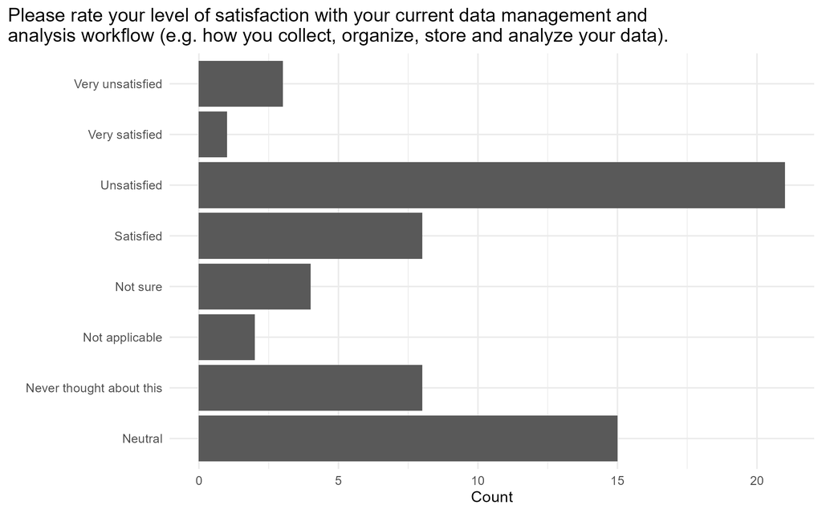

```r
knitr::include_graphics(here::here("output/survey/01-self_assessment/Q5.1.png"))
```

7.2:

- I believe having access to the original, raw data is important to be able to repeat an analysis. (1)
- I can write a small program, script, or macro to address a problem in my own work. (2)
- I know how to search for answers to my technical questions online. (3)
- While working on a programming project, if I got stuck, I can find ways of overcoming the problem. (4)
- I am confident in my ability to make use of programming software to work with data. (5)
- Using a programming language (like R or Python) can make my analyses easier to reproduce. (6)
- Using a programming language (like R or Python) can make me more efficient at working with data. (7)

```r
wide_survey_likert %>%
  dplyr::select(starts_with("Q5"), -Q5.1, Q7.2_1, Q7.2_6, Q7.2_7) %>%
  data.matrix() %>%
  alpha()
```

```
##
## Reliability analysis
## Call: alpha(x = .)
##
##   raw_alpha std.alpha G6(smc) average_r S/N   ase mean  sd median_r
##       0.75      0.71    0.78      0.37 2.4 0.045  4.8 1.2     0.27
##
##  lower alpha upper     95% confidence boundaries
## 0.66 0.75 0.83
##
##  Reliability if an item is dropped:
##        raw_alpha std.alpha G6(smc) average_r  S/N alpha se var.r med.r
## Q5.2        0.75      0.69    0.79      0.42 2.21    0.041 0.209  0.17
## Q7.2_1      0.82      0.81    0.86      0.59 4.38    0.041 0.099  0.46
## Q7.2_6      0.47      0.47    0.39      0.23 0.89    0.104 0.014  0.17
## Q7.2_7      0.52      0.50    0.44      0.25 1.02    0.091 0.033  0.15
##
##  Item statistics
##         n raw.r std.r r.cor r.drop mean   sd
## Q5.2   57  0.67  0.68  0.49   0.43  2.8 1.53
## Q7.2_1 57  0.35  0.50  0.20   0.18  6.3 0.88
## Q7.2_6 57  0.94  0.88  0.96   0.84  4.9 1.87
## Q7.2_7 57  0.91  0.85  0.93   0.78  5.1 1.88
##
## Non missing response frequency for each item
##           1    2    3    4    5    6    7 miss
## Q5.2   0.12 0.54 0.05 0.05 0.16 0.07 0.00    0
## Q7.2_1 0.00 0.00 0.00 0.05 0.12 0.33 0.49    0
## Q7.2_6 0.09 0.04 0.02 0.32 0.09 0.16 0.30    0
## Q7.2_7 0.09 0.02 0.02 0.32 0.07 0.14 0.35    0
```

```r
wide_survey_likert %>%
  dplyr::select(starts_with("Q5"), -Q5.1, Q7.2_6, Q7.2_7) %>%
  data.matrix() %>%
  alpha()
```

```
##
## Reliability analysis
## Call: alpha(x = .)
##
##   raw_alpha std.alpha G6(smc) average_r S/N   ase mean  sd median_r
##       0.82      0.81    0.86      0.59 4.4 0.041  4.3 1.5     0.46
##
##  lower alpha upper     95% confidence boundaries
## 0.74 0.82 0.91
##
##  Reliability if an item is dropped:
##        raw_alpha std.alpha G6(smc) average_r  S/N alpha se var.r med.r
## Q5.2        0.98      0.98    0.95      0.95 39.9   0.0065    NA  0.95
## Q7.2_6      0.53      0.54    0.37      0.37  1.2   0.1223    NA  0.37
## Q7.2_7      0.62      0.63    0.46      0.46  1.7   0.0972    NA  0.46
##
##  Item statistics
##         n raw.r std.r r.cor r.drop mean  sd
## Q5.2   57  0.68  0.71  0.46   0.42  2.8 1.5
## Q7.2_6 57  0.96  0.94  0.98   0.88  4.9 1.9
## Q7.2_7 57  0.92  0.90  0.94   0.80  5.1 1.9
##
## Non missing response frequency for each item
##           1    2    3    4    5    6    7 miss
## Q5.2   0.12 0.54 0.05 0.05 0.16 0.07 0.00    0
## Q7.2_6 0.09 0.04 0.02 0.32 0.09 0.16 0.30    0
## Q7.2_7 0.09 0.02 0.02 0.32 0.07 0.14 0.35    0
```

## Data + Project

```r
wide_survey_likert %>%
  dplyr::select(Q4.3, Q4.4, Q5.2, Q7.2_1, Q7.2_6, Q7.2_7) %>%
  data.matrix() %>%
  alpha()
```

```
##
## Reliability analysis
## Call: alpha(x = .)
##
##   raw_alpha std.alpha G6(smc) average_r S/N   ase mean sd median_r
##        0.8      0.78    0.82      0.37 3.6 0.035  3.8  1      0.4
##
##  lower alpha upper     95% confidence boundaries
## 0.73 0.8 0.87
##
##  Reliability if an item is dropped:
##        raw_alpha std.alpha G6(smc) average_r S/N alpha se var.r med.r
## Q4.3        0.76      0.73    0.79      0.36 2.8    0.042 0.061  0.35
## Q4.4        0.78      0.76    0.81      0.39 3.1    0.037 0.071  0.40
## Q5.2        0.78      0.75    0.80      0.38 3.0    0.036 0.072  0.39
## Q7.2_1      0.83      0.83    0.86      0.49 4.9    0.033 0.031  0.44
## Q7.2_6      0.69      0.69    0.66      0.30 2.2    0.059 0.025  0.35
## Q7.2_7      0.72      0.71    0.69      0.32 2.4    0.052 0.031  0.42
##
##  Item statistics
##         n raw.r std.r r.cor r.drop mean   sd
## Q4.3   57  0.72  0.74  0.65   0.61  2.1 1.16
## Q4.4   57  0.62  0.66  0.54   0.48  1.8 1.17
## Q5.2   57  0.68  0.68  0.57   0.50  2.8 1.53
## Q7.2_1 57  0.31  0.40  0.19   0.18  6.3 0.88
## Q7.2_6 57  0.91  0.86  0.93   0.83  4.9 1.87
## Q7.2_7 57  0.87  0.81  0.87   0.75  5.1 1.88
##
## Non missing response frequency for each item
##           1    2    3    4    5    6    7 miss
## Q4.3   0.49 0.11 0.26 0.14 0.00 0.00 0.00    0
## Q4.4   0.65 0.09 0.11 0.16 0.00 0.00 0.00    0
## Q5.2   0.12 0.54 0.05 0.05 0.16 0.07 0.00    0
## Q7.2_1 0.00 0.00 0.00 0.05 0.12 0.33 0.49    0
## Q7.2_6 0.09 0.04 0.02 0.32 0.09 0.16 0.30    0
## Q7.2_7 0.09 0.02 0.02 0.32 0.07 0.14 0.35    0
```

```r
wide_survey_likert %>%
  dplyr::select(Q4.3, Q4.4, Q5.2, Q7.2_6, Q7.2_7) %>%
  data.matrix() %>%
  alpha()
```

```
##
## Reliability analysis
## Call: alpha(x = .)
##
##   raw_alpha std.alpha G6(smc) average_r S/N   ase mean  sd median_r
##       0.83      0.83    0.86      0.49 4.9 0.033  3.3 1.2     0.44
##
##  lower alpha upper     95% confidence boundaries
## 0.76 0.83 0.89
##
##  Reliability if an item is dropped:
##        raw_alpha std.alpha G6(smc) average_r S/N alpha se  var.r med.r
## Q4.3        0.80      0.79    0.84      0.49 3.9    0.040 0.0526  0.42
## Q4.4        0.83      0.83    0.86      0.55 5.0    0.034 0.0433  0.50
## Q5.2        0.83      0.83    0.86      0.54 4.7    0.032 0.0467  0.48
## Q7.2_6      0.72      0.74    0.69      0.42 2.9    0.058 0.0044  0.42
## Q7.2_7      0.75      0.77    0.72      0.46 3.4    0.050 0.0035  0.44
##
##  Item statistics
##         n raw.r std.r r.cor r.drop mean  sd
## Q4.3   57  0.73  0.77  0.66   0.62  2.1 1.2
## Q4.4   57  0.62  0.68  0.53   0.48  1.8 1.2
## Q5.2   57  0.68  0.69  0.56   0.50  2.8 1.5
## Q7.2_6 57  0.92  0.89  0.94   0.85  4.9 1.9
## Q7.2_7 57  0.87  0.83  0.87   0.76  5.1 1.9
##
## Non missing response frequency for each item
##           1    2    3    4    5    6    7 miss
## Q4.3   0.49 0.11 0.26 0.14 0.00 0.00 0.00    0
## Q4.4   0.65 0.09 0.11 0.16 0.00 0.00 0.00    0
## Q5.2   0.12 0.54 0.05 0.05 0.16 0.07 0.00    0
## Q7.2_6 0.09 0.04 0.02 0.32 0.09 0.16 0.30    0
## Q7.2_7 0.09 0.02 0.02 0.32 0.07 0.14 0.35    0
```

```r
wide_survey_likert %>%
  dplyr::select(Q4.3, Q5.2, Q7.2_6, Q7.2_7) %>%
  data.matrix() %>%
  alpha()
```

```
##
## Reliability analysis
## Call: alpha(x = .)
##
##   raw_alpha std.alpha G6(smc) average_r S/N   ase mean  sd median_r
##       0.83      0.83    0.86      0.55   5 0.034  3.7 1.3      0.5
##
##  lower alpha upper     95% confidence boundaries
## 0.76 0.83 0.9
##
##  Reliability if an item is dropped:
##        raw_alpha std.alpha G6(smc) average_r S/N alpha se  var.r med.r
## Q4.3        0.82      0.81    0.86      0.59 4.4    0.041 0.0990  0.46
## Q5.2        0.87      0.87    0.88      0.68 6.5    0.026 0.0542  0.57
## Q7.2_6      0.68      0.71    0.63      0.45 2.4    0.071 0.0069  0.44
## Q7.2_7      0.72      0.74    0.66      0.49 2.9    0.060 0.0048  0.46
##
##  Item statistics
##         n raw.r std.r r.cor r.drop mean  sd
## Q4.3   57  0.73  0.78  0.63   0.60  2.1 1.2
## Q5.2   57  0.67  0.70  0.52   0.46  2.8 1.5
## Q7.2_6 57  0.94  0.91  0.96   0.87  4.9 1.9
## Q7.2_7 57  0.91  0.87  0.91   0.79  5.1 1.9
##
## Non missing response frequency for each item
##           1    2    3    4    5    6    7 miss
## Q4.3   0.49 0.11 0.26 0.14 0.00 0.00 0.00    0
## Q5.2   0.12 0.54 0.05 0.05 0.16 0.07 0.00    0
## Q7.2_6 0.09 0.04 0.02 0.32 0.09 0.16 0.30    0
## Q7.2_7 0.09 0.02 0.02 0.32 0.07 0.14 0.35    0
```

```r
wide_survey_likert %>%
  dplyr::select(Q4.3, Q5.2, Q7.2_6, Q7.2_7, Q6.4) %>%
  data.matrix() %>%
  alpha()
```

```
##
## Reliability analysis
## Call: alpha(x = .)
##
##   raw_alpha std.alpha G6(smc) average_r S/N   ase mean  sd median_r
##       0.81      0.81    0.85      0.45 4.1 0.037  3.4 1.2     0.45
##
##  lower alpha upper     95% confidence boundaries
## 0.74 0.81 0.88
##
##  Reliability if an item is dropped:
##        raw_alpha std.alpha G6(smc) average_r S/N alpha se var.r med.r
## Q4.3        0.78      0.76    0.84      0.45 3.3    0.046 0.078  0.41
## Q5.2        0.79      0.77    0.82      0.46 3.4    0.039 0.084  0.41
## Q7.2_6      0.69      0.72    0.69      0.39 2.5    0.064 0.018  0.40
## Q7.2_7      0.73      0.74    0.71      0.42 2.9    0.056 0.017  0.45
## Q6.4        0.83      0.83    0.86      0.55 5.0    0.034 0.043  0.50
##
##  Item statistics
##         n raw.r std.r r.cor r.drop mean  sd
## Q4.3   57  0.73  0.76  0.64   0.61  2.1 1.2
## Q5.2   57  0.71  0.74  0.64   0.54  2.8 1.5
## Q7.2_6 57  0.91  0.86  0.91   0.81  4.9 1.9
## Q7.2_7 57  0.86  0.81  0.85   0.73  5.1 1.9
## Q6.4   57  0.52  0.59  0.43   0.35  2.0 1.1
##
## Non missing response frequency for each item
##           1    2    3    4    5    6    7 miss
## Q4.3   0.49 0.11 0.26 0.14 0.00 0.00 0.00    0
## Q5.2   0.12 0.54 0.05 0.05 0.16 0.07 0.00    0
## Q7.2_6 0.09 0.04 0.02 0.32 0.09 0.16 0.30    0
## Q7.2_7 0.09 0.02 0.02 0.32 0.07 0.14 0.35    0
## Q6.4   0.46 0.21 0.18 0.16 0.00 0.00 0.00    0
```

## Statistics Q6

```r
wide_survey_likert %>%
  dplyr::select(starts_with("Q6")) %>%
  data.matrix() %>%
  alpha()
```

```
##
## Reliability analysis
## Call: alpha(x = .)
##
##   raw_alpha std.alpha G6(smc) average_r S/N   ase mean   sd median_r
##       0.87      0.87    0.88      0.63 6.9 0.031  2.5 0.87     0.63
##
##  lower alpha upper     95% confidence boundaries
## 0.8 0.87 0.93
##
##  Reliability if an item is dropped:
##      raw_alpha std.alpha G6(smc) average_r  S/N alpha se  var.r med.r
## Q6.1      0.77      0.78    0.78      0.55  3.6    0.056 0.0605  0.47
## Q6.2      0.77      0.78    0.76      0.54  3.5    0.056 0.0458  0.49
## Q6.3      0.82      0.83    0.83      0.62  4.9    0.045 0.0604  0.49
## Q6.4      0.94      0.94    0.92      0.83 14.8    0.015 0.0044  0.82
##
##  Item statistics
##       n raw.r std.r r.cor r.drop mean   sd
## Q6.1 57  0.92  0.93  0.93   0.85  2.7 1.02
## Q6.2 57  0.93  0.94  0.95   0.87  2.7 0.97
## Q6.3 57  0.85  0.86  0.82   0.74  2.6 0.98
## Q6.4 57  0.70  0.68  0.49   0.46  2.0 1.13
##
## Non missing response frequency for each item
##         1    2    3    4 miss
## Q6.1 0.19 0.14 0.46 0.21    0
## Q6.2 0.18 0.16 0.49 0.18    0
## Q6.3 0.18 0.21 0.44 0.18    0
## Q6.4 0.46 0.21 0.18 0.16    0
```

Q6.4 Are you familiar with the term “dummy variable”? It is sometimes also called “one-hot encoding”.

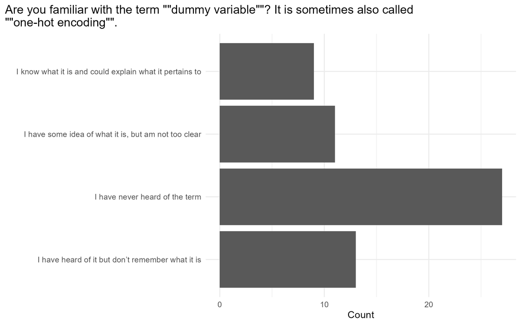

```r
knitr::include_graphics(here::here("output/survey/01-self_assessment/Q6.4.png"))
```

```r
wide_survey_likert %>%
  dplyr::select(starts_with("Q6"), -Q6.4) %>%
  data.matrix() %>%
  alpha()
```

```
##
## Reliability analysis
## Call: alpha(x = .)
##
##   raw_alpha std.alpha G6(smc) average_r S/N   ase mean   sd median_r
##       0.94      0.94    0.92      0.83  15 0.015  2.7 0.93     0.82
##
##  lower alpha upper     95% confidence boundaries
## 0.91 0.94 0.97
##
##  Reliability if an item is dropped:
##      raw_alpha std.alpha G6(smc) average_r  S/N alpha se var.r med.r
## Q6.1      0.90      0.90    0.82      0.82  9.3    0.026    NA  0.82
## Q6.2      0.87      0.87    0.77      0.77  6.7    0.034    NA  0.77
## Q6.3      0.95      0.95    0.90      0.90 18.5    0.014    NA  0.90
##
##  Item statistics
##       n raw.r std.r r.cor r.drop mean   sd
## Q6.1 57  0.95  0.95  0.92   0.88  2.7 1.02
## Q6.2 57  0.96  0.96  0.95   0.92  2.7 0.97
## Q6.3 57  0.92  0.92  0.84   0.82  2.6 0.98
##
## Non missing response frequency for each item
##         1    2    3    4 miss
## Q6.1 0.19 0.14 0.46 0.21    0
## Q6.2 0.18 0.16 0.49 0.18    0
## Q6.3 0.18 0.21 0.44 0.18    0
```

## Likert only

7.2:

- I believe having access to the original, raw data is important to be able to repeat an analysis. (1)
- I can write a small program, script, or macro to address a problem in my own work. (2)
- I know how to search for answers to my technical questions online. (3)
- While working on a programming project, if I got stuck, I can find ways of overcoming the problem. (4)
- I am confident in my ability to make use of programming software to work with data. (5)
- Using a programming language (like R or Python) can make my analyses easier to reproduce. (6)
- Using a programming language (like R or Python) can make me more efficient at working with data. (7)

```r
wide_survey_likert %>%
  dplyr::select(starts_with("Q7")) %>%
  data.matrix() %>%
  alpha()
```

```
##
## Reliability analysis
## Call: alpha(x = .)
##
##   raw_alpha std.alpha G6(smc) average_r S/N   ase mean  sd median_r
##       0.89      0.88    0.93      0.51 7.3 0.018  4.7 1.4     0.59
##
##  lower alpha upper     95% confidence boundaries
## 0.86 0.89 0.93
##
##  Reliability if an item is dropped:
##        raw_alpha std.alpha G6(smc) average_r  S/N alpha se var.r med.r
## Q7.2_1      0.92      0.92    0.95      0.67 11.9    0.016 0.017  0.62
## Q7.2_2      0.86      0.85    0.90      0.48  5.5    0.024 0.076  0.56
## Q7.2_3      0.88      0.85    0.91      0.49  5.7    0.021 0.101  0.57
## Q7.2_4      0.87      0.85    0.91      0.48  5.6    0.023 0.081  0.57
## Q7.2_5      0.87      0.85    0.90      0.49  5.7    0.023 0.073  0.57
## Q7.2_6      0.87      0.85    0.88      0.48  5.5    0.022 0.082  0.56
## Q7.2_7      0.87      0.86    0.88      0.50  5.9    0.020 0.086  0.61
##
##  Item statistics
##         n raw.r std.r r.cor r.drop mean   sd
## Q7.2_1 57  0.22  0.33  0.18   0.13  6.3 0.88
## Q7.2_2 57  0.89  0.85  0.85   0.82  3.2 2.30
## Q7.2_3 57  0.80  0.83  0.78   0.73  5.5 1.43
## Q7.2_4 57  0.86  0.84  0.82   0.80  4.2 1.89
## Q7.2_5 57  0.87  0.83  0.82   0.80  3.5 2.18
## Q7.2_6 57  0.86  0.85  0.87   0.80  4.9 1.87
## Q7.2_7 57  0.81  0.81  0.82   0.72  5.1 1.88
##
## Non missing response frequency for each item
##           1    2    3    4    5    6    7 miss
## Q7.2_1 0.00 0.00 0.00 0.05 0.12 0.33 0.49    0
## Q7.2_2 0.37 0.16 0.09 0.05 0.11 0.07 0.16    0
## Q7.2_3 0.02 0.05 0.04 0.04 0.32 0.30 0.25    0
## Q7.2_4 0.14 0.05 0.12 0.23 0.19 0.12 0.14    0
## Q7.2_5 0.28 0.14 0.14 0.07 0.12 0.12 0.12    0
## Q7.2_6 0.09 0.04 0.02 0.32 0.09 0.16 0.30    0
## Q7.2_7 0.09 0.02 0.02 0.32 0.07 0.14 0.35    0
```

```r
wide_survey_likert %>%
  dplyr::select(starts_with("Q7"), -Q7.2_1) %>%
  data.matrix() %>%
  alpha()
```

```
##
## Reliability analysis
## Call: alpha(x = .)
##
##   raw_alpha std.alpha G6(smc) average_r S/N   ase mean  sd median_r
##       0.92      0.92    0.95      0.67  12 0.016  4.4 1.6     0.62
##
##  lower alpha upper     95% confidence boundaries
## 0.89 0.92 0.95
##
##  Reliability if an item is dropped:
##        raw_alpha std.alpha G6(smc) average_r  S/N alpha se  var.r med.r
## Q7.2_2      0.90      0.90    0.93      0.65  9.2    0.022 0.0183  0.60
## Q7.2_3      0.92      0.92    0.95      0.69 11.0    0.019 0.0227  0.63
## Q7.2_4      0.90      0.91    0.94      0.66  9.6    0.021 0.0199  0.61
## Q7.2_5      0.90      0.91    0.93      0.66  9.5    0.021 0.0158  0.62
## Q7.2_6      0.90      0.91    0.90      0.66  9.6    0.019 0.0150  0.63
## Q7.2_7      0.91      0.92    0.91      0.68 10.8    0.017 0.0096  0.64
##
##  Item statistics
##         n raw.r std.r r.cor r.drop mean  sd
## Q7.2_2 57  0.90  0.88  0.86   0.83  3.2 2.3
## Q7.2_3 57  0.78  0.80  0.73   0.71  5.5 1.4
## Q7.2_4 57  0.87  0.87  0.83   0.80  4.2 1.9
## Q7.2_5 57  0.88  0.87  0.85   0.81  3.5 2.2
## Q7.2_6 57  0.86  0.86  0.87   0.79  4.9 1.9
## Q7.2_7 57  0.80  0.81  0.81   0.72  5.1 1.9
##
## Non missing response frequency for each item
##           1    2    3    4    5    6    7 miss
## Q7.2_2 0.37 0.16 0.09 0.05 0.11 0.07 0.16    0
## Q7.2_3 0.02 0.05 0.04 0.04 0.32 0.30 0.25    0
## Q7.2_4 0.14 0.05 0.12 0.23 0.19 0.12 0.14    0
## Q7.2_5 0.28 0.14 0.14 0.07 0.12 0.12 0.12    0
## Q7.2_6 0.09 0.04 0.02 0.32 0.09 0.16 0.30    0
## Q7.2_7 0.09 0.02 0.02 0.32 0.07 0.14 0.35    0
```